# Week 9: Descriptive Statistics and Data Analysis

Understanding Your Business Data Through Statistics

Course: ISM4641 Python for Business Analytics

Instructor: Dr. Smith • Version: 0.12.0 • University of South Florida

# Week 9: Descriptive Statistics and Data Analysis

## Introduction

This week, we’ll explore how to use descriptive statistics to understand and analyze business data. Descriptive statistics help us summarize complex datasets into meaningful insights that drive business decisions.

### Why Statistics Matter in Business

- **Summarize Complex Data**: Turn thousands of records into key insights
- **Identify Patterns**: Discover trends and outliers
- **Make Comparisons**: Benchmark performance
- **Support Decisions**: Evidence-based business choices

# Part 1: Measures of Central Tendency

## Understanding Your Data’s Center

Central tendency measures help us understand the “typical” or “central” value in our dataset.

### The Three Main Measures

1. **Mean (Average)**: Sum of all values divided by count
2. **Median**: Middle value when sorted
3. **Mode**: Most frequently occurring value

```python
import pandas as pd
import numpy as np
import matplotlib.pyplot as plt
import seaborn as sns

# Set style for professional appearance
plt.style.use('default')
sns.set_palette("husl")

# Create sample business data
np.random.seed(42)
sales_data = pd.DataFrame({
    'Store_ID': [f'S{i:03d}' for i in range(1, 101)],
    'Monthly_Sales': np.random.normal(50000, 15000, 100),
    'Customer_Count': np.random.poisson(500, 100),
    'Avg_Transaction': np.random.normal(75, 20, 100)
})

# Calculate central tendency
mean_sales = sales_data['Monthly_Sales'].mean()
median_sales = sales_data['Monthly_Sales'].median()
mode_sales = sales_data['Monthly_Sales'].mode()

print(f"Sales Analysis:")
print(f"Mean: ${mean_sales:,.2f}")
print(f"Median: ${median_sales:,.2f}")
print(f"Mode: {mode_sales.values[0] if len(mode_sales) > 0 else 'No clear mode'}")
```

```
Sales Analysis:
Mean: $48,442.30
Median: $48,095.66
Mode: 10703.823438653832
```

### When to Use Each Measure

- **Mean**: Best for normally distributed data without outliers
- **Median**: Robust to outliers, better for skewed data
- **Mode**: Categorical data or finding most common values

# Part 2: Measures of Variability

## Understanding Data Spread

Imagine two retail stores both averaging $50,000 in monthly sales. Sound identical? Not quite!

**Store A**: $49K, $50K, $51K, $50K, $49K, $51K (very consistent, predictable) **Store B**: $20K, $80K, $30K, $70K, $40K, $60K (highly variable, unpredictable)

Both average $50,000, but they’re completely different! This is why we need **variability** measures - they tell us HOW MUCH data points differ from each other and from the average.

### Why Variability Matters in Business

Understanding variability is crucial for:

1. **Forecasting**: Low variability = easier to predict future performance
2. **Quality Control**: Consistent products = satisfied customers
3. **Risk Assessment**: High variability = higher uncertainty and risk
4. **Resource Planning**: Predictable demand = efficient inventory management
5. **Performance Evaluation**: Identify inconsistent processes that need attention

**Think of it this way:** - **Low variability** = Predictable, consistent, reliable, easier to manage - **High variability** = Unpredictable, volatile, risky, harder to plan for

### The Five Key Variability Measures

Let’s explore each measure and understand when to use it:

#### 1. Range - The Simplest Measure

**What it is**: The difference between the highest and lowest values.

**Formula**: `Range = Maximum - Minimum`

**Example**: If your daily sales range from $1,000 (min) to $5,000 (max), the range is $4,000.

**Pros**: - Extremely simple to calculate and understand - Shows the full spread of your data

**Cons**: - Only uses two values (ignores everything in between) - Very sensitive to outliers (one extreme value skews it)

**When to use**: Quick estimates, initial data exploration

#### 2. Variance - The Foundation

**What it is**: Average of the squared differences from the mean.

**Formula**: `Variance = Σ(x - mean)² / n`

**How it works** (step by step): 1. Find the mean of all values 2. Subtract the mean from each value (these are “deviations”) 3. Square each deviation (makes negatives positive, emphasizes large differences) 4. Average all the squared deviations

**Example**: - Data: [10, 12, 14, 16, 18], Mean = 14 - Deviations: [-4, -2, 0, +2, +4] - Squared: [16, 4, 0, 4, 16] - Variance = (16+4+0+4+16)/5 = 8

**Cons**: - Units are squared (dollars² doesn’t make intuitive sense) - Hard to interpret for non-technical audiences

**When to use**: Statistical calculations, building models (rarely reported directly)

#### 3. Standard Deviation - The Most Important!

**What it is**: The square root of variance (brings units back to original scale).

**Formula**: `Standard Deviation (σ) = √Variance`

**Why it’s the most used**: - Same units as your original data (dollars, not dollars²) - Intuitive to interpret - Tells you the “typical” distance from the mean

**The Empirical Rule** (for normal distributions): - **68%** of data falls within Mean ± 1 standard deviation - **95%** of data falls within Mean ± 2 standard deviations - **99.7%** of data falls within Mean ± 3 standard deviations

**Business Example**: - Mean monthly sales: $50,000 - Standard Deviation: $10,000 - Interpretation: “Most months (68%) we sell between $40K and $60K; almost all months (95%) we sell between $30K and $70K”

**When to use**: Almost always! It’s the standard choice for measuring variability.

#### 4. Interquartile Range (IQR) - The Robust Measure

**What it is**: The range of the middle 50% of data (from Q1 to Q3).

**Formula**: `IQR = Q3 - Q1` (75th percentile - 25th percentile)

**Why it’s robust**: Ignores the extreme 25% on each end, so outliers don’t affect it.

**Business Example**: If IQR = $20,000 for store sales, the middle half of stores have sales spanning a $20,000 range. Stores in the bottom 25% and top 25% don’t influence this number.

**Outlier Detection Rule**: - **Lower fence**: Q1 - 1.5 × IQR - **Upper fence**: Q3 + 1.5 × IQR - Values outside these fences are considered outliers

**When to use**: Data with outliers, skewed distributions, robust analysis

### Calculating Variability Measures for Our Data

```python
# Calculate all variability measures
variance = sales_data['Monthly_Sales'].var()
std_dev = sales_data['Monthly_Sales'].std()
data_range = sales_data['Monthly_Sales'].max() - sales_data['Monthly_Sales'].min()
Q1 = sales_data['Monthly_Sales'].quantile(0.25)
Q3 = sales_data['Monthly_Sales'].quantile(0.75)
iqr = Q3 - Q1

print("="*70)
print("VARIABILITY ANALYSIS: Monthly Sales")
print("="*70)
print(f"\n1. Range (Max - Min):")
print(f"   Value: ${data_range:,.2f}")
print(f"   Interpretation: Sales span from lowest to highest by ${data_range:,.2f}")

print(f"\n2. Variance:")
print(f"   Value: ${variance:,.2f}²")
print(f"   Interpretation: Average squared deviation (hard to interpret directly)")

print(f"\n3. Standard Deviation (Most Important!):")
print(f"   Value: ${std_dev:,.2f}")
print(f"   Interpretation: Typical distance from the mean is ${std_dev:,.2f}")
print(f"   68% of stores sell between ${mean_sales - std_dev:,.0f} and ${mean_sales + std_dev:,.0f}")
print(f"   95% of stores sell between ${mean_sales - 2*std_dev:,.0f} and ${mean_sales + 2*std_dev:,.0f}")

print(f"\n4. Interquartile Range (IQR):")
print(f"   Value: ${iqr:,.2f}")
print(f"   Interpretation: Middle 50% of stores span ${iqr:,.2f} in sales")

# Calculate outlier fences
lower_fence = Q1 - 1.5 * iqr
upper_fence = Q3 + 1.5 * iqr
outliers = sales_data[(sales_data['Monthly_Sales'] < lower_fence) |
                      (sales_data['Monthly_Sales'] > upper_fence)]

print(f"\n5. Outlier Detection:")
print(f"   Lower fence: ${lower_fence:,.2f}")
print(f"   Upper fence: ${upper_fence:,.2f}")
print(f"   Number of outliers: {len(outliers)}")
if len(outliers) > 0:
    print(f"   Outlier percentage: {len(outliers)/len(sales_data)*100:.1f}%")
    print(f"   These stores need investigation!")

print("="*70)
```

```
======================================================================
VARIABILITY ANALYSIS: Monthly Sales
======================================================================

1. Range (Max - Min):
   Value: $67,080.35
   Interpretation: Sales span from lowest to highest by $67,080.35

2. Variance:
   Value: $185,573,226.07²
   Interpretation: Average squared deviation (hard to interpret directly)

3. Standard Deviation (Most Important!):
   Value: $13,622.53
   Interpretation: Typical distance from the mean is $13,622.53
   68% of stores sell between $34,820 and $62,065
   95% of stores sell between $21,197 and $75,687

4. Interquartile Range (IQR):
   Value: $15,102.87
   Interpretation: Middle 50% of stores span $15,102.87 in sales

5. Outlier Detection:
   Lower fence: $18,332.12
   Upper fence: $78,743.58
   Number of outliers: 1
   Outlier percentage: 1.0%
   These stores need investigation!
======================================================================
```

### Coefficient of Variation (CV)

#### What is the Coefficient of Variation?

The **Coefficient of Variation (CV)** is a standardized measure of variability that expresses the standard deviation as a percentage of the mean. It’s one of the most useful statistics in business because it allows you to compare the consistency of completely different measurements.

#### Why Do We Need It?

Imagine you’re comparing two aspects of your business:

- **Monthly Sales**: Mean = $50,000, Standard Deviation = $10,000
- **Customer Count**: Mean = 500, Standard Deviation = 75

Which is more variable? You can’t directly compare $10,000 to 75 - they’re in completely different units! This is where CV helps.

#### The Formula

$$CV = \frac{\text{Standard Deviation}}{\text{Mean}} \times 100$$

This converts the standard deviation into a **percentage of the mean**, making it unit-free and comparable across different measures.

#### Interpreting CV Values

- **CV < 15%**: Low variability (very consistent, predictable)
- **CV 15-30%**: Moderate variability (some variation, fairly predictable)
- **CV > 30%**: High variability (inconsistent, harder to predict)

#### Business Example

Let’s say you manage two product lines:

**Product A (Premium Watches)**: - Mean price: $5,000 - Standard Deviation: $1,000 - CV = ($1,000 / $5,000) × 100 = **20%**

**Product B (Coffee Mugs)**: - Mean price: $15 - Standard Deviation: $3 - CV = ($3 / $15) × 100 = **20%**

Even though the standard deviations are vastly different ($1,000 vs $3), both products have the **same relative variability** (20%). This tells you both product lines have similar pricing consistency relative to their price points.

#### When to Use CV

1. **Comparing different metrics**: Sales vs. customer count vs. inventory levels
2. **Comparing across different scales**: Small stores vs. large stores
3. **Quality control**: Assessing consistency in manufacturing
4. **Risk assessment**: Comparing volatility of different investments

```python
# Calculate CV for our sales data
cv = (std_dev / mean_sales) * 100
print(f"\nCoefficient of Variation Analysis:")
print(f"=" * 50)
print(f"Mean Sales: ${mean_sales:,.2f}")
print(f"Std Deviation: ${std_dev:,.2f}")
print(f"Coefficient of Variation: {cv:.2f}%")
print()

# Interpret the CV
if cv < 15:
    interpretation = "Low variability - Sales are very consistent"
    recommendation = "Predictable revenue, easy to forecast"
elif cv < 30:
    interpretation = "Moderate variability - Some fluctuation in sales"
    recommendation = "Generally predictable with some variation"
else:
    interpretation = "High variability - Sales fluctuate significantly"
    recommendation = "Difficult to forecast, investigate causes"

print(f"Interpretation: {interpretation}")
print(f"Business Impact: {recommendation}")
```

```
Coefficient of Variation Analysis:
==================================================
Mean Sales: $48,442.30
Std Deviation: $13,622.53
Coefficient of Variation: 28.12%

Interpretation: Moderate variability - Some fluctuation in sales
Business Impact: Generally predictable with some variation
```

# Part 3: Distribution Analysis

## Understanding Data Patterns Through Percentiles

So far, we’ve learned about the “center” (mean, median) and the “spread” (standard deviation, IQR) of data. Now let’s explore **percentiles** - powerful tools that help us understand exactly WHERE our data points fall within the overall distribution.

### What are Percentiles?

A **percentile** is a value below which a certain percentage of your data falls.

Think of percentiles as “dividing lines” that split your data into groups based on ranking.

#### Real-World Analogy: Test Scores

You’ve probably encountered percentiles before:

- “You scored in the 90th percentile” means you scored better than 90% of test-takers
- “You’re at the 50th percentile” means you’re exactly average (half scored below you, half above)
- “You’re in the 25th percentile” means 75% scored higher than you

The same concept applies to business data!

### Understanding Quartiles - The Most Important Percentiles

**Quartiles** divide your data into four equal parts (quarters):

```
|----25%----|----25%----|----25%----|----25%----|
Min         Q1         Q2          Q3         Max
            (25th)     (50th)      (75th)
                       Median
```

**Q1 (First Quartile / 25th Percentile)**: - 25% of data falls below this value - 75% of data falls above this value - Marks the bottom of the “middle 50%”

**Q2 (Second Quartile / 50th Percentile / Median)**: - The middle value - 50% of data below, 50% above - This is the median we learned about earlier!

**Q3 (Third Quartile / 75th Percentile)**: - 75% of data falls below this value - 25% of data falls above this value - Marks the top of the “middle 50%”

**IQR (Interquartile Range)**: The distance from Q1 to Q3, containing the middle 50% of your data

### Business Example: Understanding Employee Salaries

Let’s say you analyze salaries at your company:

- **Min**: $30,000
- **Q1 (25th)**: $45,000
- **Q2 (50th/Median)**: $60,000
- **Q3 (75th)**: $80,000
- **Max**: $150,000

**What this tells you:**

1. **Bottom 25%**: Earn less than $45K (entry-level, part-time workers)
2. **Middle 50%**: Earn between $45K and $80K (core workforce)
3. **Top 25%**: Earn more than $80K (senior staff, specialists)
4. **Typical salary**: $60K (median)
5. **Middle range spread**: $35K ($45K to $80K = IQR)

### Common Percentiles and Their Business Uses

**P10 (10th Percentile)**: - Bottom 10% of values - “What’s the minimum acceptable performance?” - Used to identify underperformers

**P25 (Q1)**: - Bottom quarter boundary - “Below-average” threshold

**P50 (Median)**: - The middle, typical value - “Average” performance benchmark

**P75 (Q3)**: - Top quarter entry point - “Above-average” threshold

**P90 (90th Percentile)**: - Top 10% of values - “What does excellent performance look like?” - Used to identify high performers

**P95, P99**: - Extreme high values - Capacity planning, worst-case scenarios - “What’s our maximum expected value?”

### Important: Percentile ≠ Percentage!

**⚠️ Common Confusion Alert!**

- **Percentile**: A **position in rank order**
  - Example: “You’re at the 80th percentile” = you’re in the top 20%
- **Percentage**: A **portion of the whole**
  - Example: “You scored 80%” = 80 out of 100 points

**Real example to clarify:** - Scoring **70%** on a test (percentage of correct answers) - Being in the **90th percentile** (ranking higher than 90% of students) - You can score 70% and still be in the 90th percentile if most students did poorly!

### Calculating Percentiles for Our Sales Data

```python
# Calculate key percentiles
percentiles = [10, 25, 50, 75, 90, 95]

print("="*70)
print("PERCENTILE ANALYSIS: Monthly Store Sales")
print("="*70)
print()

for p in percentiles:
    value = sales_data['Monthly_Sales'].quantile(p/100)
    below = p
    above = 100 - p

    print(f"{p:3d}th Percentile: ${value:>12,.2f}")
    print(f"     → {below}% of stores sell LESS than ${value:,.2f}")
    print(f"     → {above}% of stores sell MORE than ${value:,.2f}")
    print()

# Business insights
p10 = sales_data['Monthly_Sales'].quantile(0.10)
p90 = sales_data['Monthly_Sales'].quantile(0.90)

print("="*70)
print("BUSINESS INSIGHTS FROM PERCENTILES")
print("="*70)
print(f"\n🎯 Top Performers (90th percentile and above):")
print(f"   These stores earn ${p90:,.2f} or more per month")
print(f"   Only 10% of stores achieve this level")

print(f"\n⚠️  Low Performers (10th percentile and below):")
print(f"   These stores earn ${p10:,.2f} or less per month")
print(f"   These 10% of stores may need support")

print(f"\n📊 Performance Spread:")
print(f"   Gap between top 10% and bottom 10%: ${p90 - p10:,.2f}")
print(f"   This shows the range of performance variability")

print("="*70)
```

```
======================================================================
PERCENTILE ANALYSIS: Monthly Store Sales
======================================================================

 10th Percentile: $   29,951.03
     → 10% of stores sell LESS than $29,951.03
     → 90% of stores sell MORE than $29,951.03

 25th Percentile: $   40,986.41
     → 25% of stores sell LESS than $40,986.41
     → 75% of stores sell MORE than $40,986.41

 50th Percentile: $   48,095.66
     → 50% of stores sell LESS than $48,095.66
     → 50% of stores sell MORE than $48,095.66

 75th Percentile: $   56,089.28
     → 75% of stores sell LESS than $56,089.28
     → 25% of stores sell MORE than $56,089.28

 90th Percentile: $   65,094.19
     → 90% of stores sell LESS than $65,094.19
     → 10% of stores sell MORE than $65,094.19

 95th Percentile: $   72,202.26
     → 95% of stores sell LESS than $72,202.26
     → 5% of stores sell MORE than $72,202.26

======================================================================
BUSINESS INSIGHTS FROM PERCENTILES
======================================================================

🎯 Top Performers (90th percentile and above):
   These stores earn $65,094.19 or more per month
   Only 10% of stores achieve this level

⚠️  Low Performers (10th percentile and below):
   These stores earn $29,951.03 or less per month
   These 10% of stores may need support

📊 Performance Spread:
   Gap between top 10% and bottom 10%: $35,143.16
   This shows the range of performance variability
======================================================================
```

### Visualizing Distributions

#### 3.1 Histogram - Understanding Frequency Distributions

##### What is a Histogram?

A **histogram** groups your data into “bins” (ranges) and counts how many values fall into each bin. Think of it as creating a bar chart of your data’s frequency - it shows you WHERE your values are concentrated.

**Key Components:**

- **Bins (x-axis)**: Ranges of values (e.g., $40K-$45K, $45K-$50K)
- **Frequency (y-axis)**: How many data points fall in each bin
- **Bar height**: Taller bars = more values in that range
- **Bar width**: The size of each bin (can be adjusted)

##### How to Read a Histogram

**Look for these patterns:**

- **Bell-shaped (symmetric)**: Most values in the middle, fewer at extremes → Normal distribution
- **Right-skewed**: Long tail to the right → Few very high values
- **Left-skewed**: Long tail to the left → Few very low values
- **Multiple peaks**: Suggests distinct groups or subpopulations
- **Gaps**: Missing values or natural breaks in the data
- **Outliers**: Isolated bars far from the main cluster

##### Business Applications

**When to use histograms in business:**

1. **Sales Analysis**: Understand distribution of daily/monthly sales
   - “Are most days clustered around a typical value, or all over the place?”
2. **Customer Behavior**: Analyze purchase amounts
   - “Do most customers spend around the same amount, or is there huge variation?”
3. **Quality Control**: Monitor product measurements
   - “Are widget dimensions consistent, or too variable?”
4. **HR Analytics**: Understand salary distributions
   - “Is pay evenly distributed, or are there clusters?”
5. **Website Traffic**: Visualize page load times
   - “Are most pages fast, with a few slow outliers?”

##### Business Example: Store Sales Distribution

Imagine you manage 100 retail stores. A histogram of monthly sales tells you:

- **Clustered around $50K**: Most stores perform similarly (good - predictable!)
- **Wide spread**: Stores vary wildly (concerning - why the inconsistency?)
- **Two peaks**: You might have two distinct store types (e.g., urban vs. suburban)
- **Outliers on right**: A few star performers to study and replicate
- **Outliers on left**: Problem stores needing attention

##### Creating a Histogram for Our Sales Data

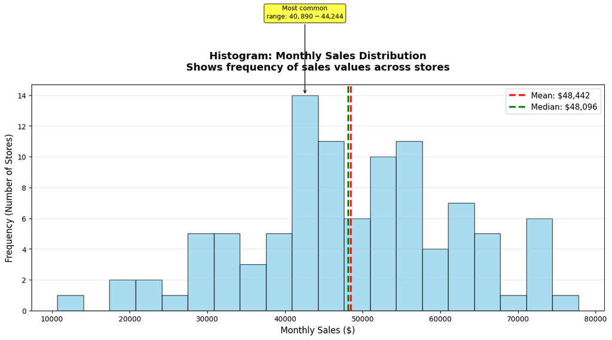

```
Histogram Interpretation:
======================================================================
Most stores (14 stores) have sales in the
$40,890 - $44,244 range

This histogram shows us the overall SHAPE and SPREAD of store performance
======================================================================
```

```python
# Create histogram with detailed annotations
fig, ax = plt.subplots(figsize=(12, 7))

# Create histogram
n, bins, patches = ax.hist(sales_data['Monthly_Sales'], bins=20,
                           alpha=0.7, color='skyblue', edgecolor='black')

# Add mean and median lines
ax.axvline(mean_sales, color='red', linestyle='--', linewidth=2.5,
           label=f'Mean: ${mean_sales:,.0f}')
ax.axvline(median_sales, color='green', linestyle='--', linewidth=2.5,
           label=f'Median: ${median_sales:,.0f}')

# Styling
ax.set_title('Histogram: Monthly Sales Distribution\nShows frequency of sales values across stores',
             fontsize=14, fontweight='bold', pad=20)
ax.set_xlabel('Monthly Sales ($)', fontsize=12)
ax.set_ylabel('Frequency (Number of Stores)', fontsize=12)
ax.legend(fontsize=11, loc='upper right')
ax.grid(True, axis='y', alpha=0.3)

# Add annotations
max_freq_idx = np.argmax(n)
max_freq_bin = (bins[max_freq_idx] + bins[max_freq_idx + 1]) / 2
ax.annotate(f'Most common\nrange: ${bins[max_freq_idx]:,.0f}-${bins[max_freq_idx+1]:,.0f}',
            xy=(max_freq_bin, n[max_freq_idx]),
            xytext=(max_freq_bin, n[max_freq_idx] + 5),
            ha='center', fontsize=9,
            bbox=dict(boxstyle='round', facecolor='yellow', alpha=0.7),
            arrowprops=dict(arrowstyle='->', color='black'))

plt.tight_layout()
plt.show()

print("\nHistogram Interpretation:")
print("="*70)
print(f"Most stores ({int(n[max_freq_idx])} stores) have sales in the")
print(f"${bins[max_freq_idx]:,.0f} - ${bins[max_freq_idx+1]:,.0f} range")
print(f"\nThis histogram shows us the overall SHAPE and SPREAD of store performance")
print("="*70)
```

#### 3.2 Box Plot - Visualizing Quartiles and Outliers

##### What is a Box Plot?

A **box plot** (box-and-whisker plot) is a compact visualization that shows five key numbers plus outliers in one simple graphic. It’s perfect for quickly comparing distributions and spotting unusual values.

**The Five Numbers (Five-Number Summary):**

1. **Minimum**: Lowest value (or lower fence if outliers exist)
2. **Q1 (25th percentile)**: Bottom of the box
3. **Median (50th percentile)**: Line inside the box
4. **Q3 (75th percentile)**: Top of the box
5. **Maximum**: Highest value (or upper fence if outliers exist)

**Visual Components:**

- **Box**: Contains the middle 50% of your data (IQR = Q3 - Q1)
- **Line in box**: The median (50th percentile)
- **Whiskers**: Extend to the minimum and maximum (or to fences)
- **Individual dots**: Outliers beyond the whiskers

##### How to Read a Box Plot

**What to look for:**

- **Box size (IQR)**: Large box = high variability in the middle 50%
- **Median position**: Centered = symmetric; off-center = skewed
- **Whisker length**: Long whiskers = more extreme values
- **Outlier dots**: Values that are statistically unusual
- **Comparing boxes**: Easy to compare multiple groups side-by-side

##### Business Applications

**When to use box plots in business:**

1. **Comparing Groups**: Compare sales across regions, products, or time periods
   - “Which region has the most consistent sales?”
2. **Outlier Detection**: Quickly identify unusual values
   - “Which stores are performing exceptionally well or poorly?”
3. **Quality Control**: Monitor process consistency
   - “Are our manufacturing tolerances being met?”
4. **Salary Analysis**: Understand compensation distribution
   - “Where does the ‘typical’ employee fall in the salary range?”
5. **Performance Reviews**: Visualize team or individual metrics
   - “Is this person’s performance typical or exceptional?”

##### Business Example: Regional Store Comparison

Imagine comparing sales across four regions using box plots:

- **Region A**: Small box, short whiskers → Very consistent stores
- **Region B**: Large box, long whiskers → High variability (why?)
- **Region C**: Many outliers above → Several star performers to study
- **Region D**: Outliers below → Problem stores needing intervention

The median line position tells you if sales are evenly distributed or skewed within each region.

##### Creating a Box Plot for Our Sales Data

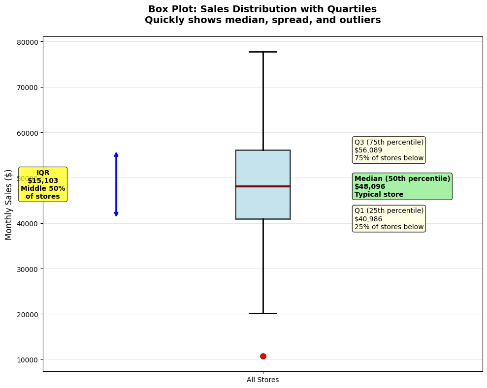

```
Box Plot Interpretation:
======================================================================
Middle 50% of stores: $40,986 to $56,089 (IQR = $15,103)
Median (typical store): $48,096
Number of outlier stores: 1
Outlier range: $10,704 to $10,704
These 1 stores need special attention!
======================================================================
```

```python
# Create detailed box plot
fig, ax = plt.subplots(figsize=(10, 8))

# Create box plot
bp = ax.boxplot(sales_data['Monthly_Sales'], vert=True, patch_artist=True,
                boxprops=dict(facecolor='lightblue', alpha=0.7, linewidth=2),
                medianprops=dict(color='darkred', linewidth=3),
                whiskerprops=dict(linewidth=2),
                capprops=dict(linewidth=2),
                flierprops=dict(marker='o', markerfacecolor='red', markersize=8,
                               markeredgecolor='darkred'))

# Calculate values for annotations
Q1 = sales_data['Monthly_Sales'].quantile(0.25)
Q3 = sales_data['Monthly_Sales'].quantile(0.75)
iqr = Q3 - Q1
lower_fence = Q1 - 1.5 * iqr
upper_fence = Q3 + 1.5 * iqr

# Add detailed annotations
ax.text(1.25, Q1, f'Q1 (25th percentile)\n${Q1:,.0f}\n25% of stores below',
        va='center', fontsize=10, bbox=dict(boxstyle='round', facecolor='lightyellow', alpha=0.8))
ax.text(1.25, median_sales, f'Median (50th percentile)\n${median_sales:,.0f}\nTypical store',
        va='center', fontsize=10, fontweight='bold',
        bbox=dict(boxstyle='round', facecolor='lightgreen', alpha=0.8))
ax.text(1.25, Q3, f'Q3 (75th percentile)\n${Q3:,.0f}\n75% of stores below',
        va='center', fontsize=10, bbox=dict(boxstyle='round', facecolor='lightyellow', alpha=0.8))

# Annotate IQR
ax.annotate('', xy=(0.6, Q1), xytext=(0.6, Q3),
            arrowprops=dict(arrowstyle='<->', color='blue', lw=2.5))
ax.text(0.4, (Q1+Q3)/2, f'IQR\n${iqr:,.0f}\nMiddle 50%\nof stores',
        ha='center', va='center', fontsize=10, fontweight='bold',
        bbox=dict(boxstyle='round', facecolor='yellow', alpha=0.7))

# Styling
ax.set_ylabel('Monthly Sales ($)', fontsize=12)
ax.set_title('Box Plot: Sales Distribution with Quartiles\nQuickly shows median, spread, and outliers',
             fontsize=14, fontweight='bold', pad=20)
ax.set_xticklabels(['All Stores'])
ax.grid(True, axis='y', alpha=0.3)
ax.set_xlim(0.4, 1.6)

plt.tight_layout()
plt.show()

# Identify outliers
outliers = sales_data[(sales_data['Monthly_Sales'] < lower_fence) |
                      (sales_data['Monthly_Sales'] > upper_fence)]

print("\nBox Plot Interpretation:")
print("="*70)
print(f"Middle 50% of stores: ${Q1:,.0f} to ${Q3:,.0f} (IQR = ${iqr:,.0f})")
print(f"Median (typical store): ${median_sales:,.0f}")
print(f"Number of outlier stores: {len(outliers)}")
if len(outliers) > 0:
    print(f"Outlier range: ${outliers['Monthly_Sales'].min():,.0f} to ${outliers['Monthly_Sales'].max():,.0f}")
    print(f"These {len(outliers)} stores need special attention!")
print("="*70)
```

#### 3.3 Density Plot - Smooth Distribution Curves

##### What is a Density Plot?

A **density plot** (also called kernel density estimate or KDE) is like a smoothed histogram - instead of discrete bars, it shows a continuous curve representing data density.

Think of it as answering: “How likely am I to find a value in this range?”

**Key Difference from Histogram:**

- **Histogram**: “There are 15 stores with sales between $45K-$50K” (counts)
- **Density Plot**: “The peak around $47K shows this is the most likely sales value” (probability)

##### How to Read a Density Plot

**Understanding the curve:**

- **Peaks (high points)**: Where data is concentrated
  - Highest peak = most common values
- **Height (y-axis)**: Probability density (not actual counts)
  - Higher curve = more likely to find values there
- **Width**: How spread out the data is
  - Narrow peak = concentrated, consistent values
  - Wide spread = variable values
- **Multiple peaks (bimodal/multimodal)**: Distinct groups in data
  - Example: Two peaks might indicate urban vs. rural stores
- **Tails**: Extent of extreme values
  - Long right tail = some very high values
  - Long left tail = some very low values

##### Advantages Over Histograms

**Why use density plots:**

1. **Smoother visualization**: No artificial “jaggedness” from bins
2. **Not affected by bin size**: Histograms look different with different bin widths
3. **Better for overlaying**: Easy to compare multiple distributions on one plot
4. **Shows underlying pattern**: Reveals the true shape of the distribution
5. **Professional appearance**: Polished look for presentations

##### Business Applications

**When to use density plots in business:**

1. **Comparing Multiple Groups**: Overlay distributions of different products, regions, time periods
   - “How do sales distributions compare across our three product lines?”
2. **Before/After Analysis**: Compare performance before and after an intervention
   - “Did sales distribution change after our marketing campaign?”
3. **Market Segmentation**: Visualize customer segments
   - “Do we have distinct customer spending patterns?”
4. **Risk Analysis**: Understand distribution of returns, losses, or risks
   - “What’s the shape of our profit/loss distribution?”
5. **Quality Monitoring**: Track if process distribution shifts over time
   - “Is our production quality distribution stable?”

##### Business Example: Product Line Comparison

Imagine comparing three product lines’ sales using density plots:

- **Product A**: Tall narrow peak → Very consistent sales, predictable
- **Product B**: Wide flat distribution → Highly variable, hard to forecast
- **Product C**: Two peaks → Two distinct customer segments or markets

Overlaying all three on one plot makes comparison easy and visually clear.

##### Creating a Density Plot for Our Sales Data

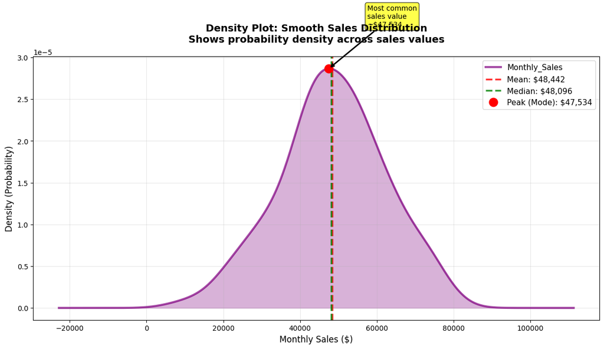

[output not shown]

```python
# Create detailed density plot
fig, ax = plt.subplots(figsize=(12, 7))

# Create density plot
sales_data['Monthly_Sales'].plot(kind='density', ax=ax,
                                  color='purple', linewidth=3, alpha=0.7)

# Fill under the curve
kde_x = ax.get_lines()[0].get_xdata()
kde_y = ax.get_lines()[0].get_ydata()
ax.fill_between(kde_x, kde_y, alpha=0.3, color='purple')

# Add mean and median lines
ax.axvline(mean_sales, color='red', linestyle='--', linewidth=2.5,
           label=f'Mean: ${mean_sales:,.0f}', alpha=0.8)
ax.axvline(median_sales, color='green', linestyle='--', linewidth=2.5,
           label=f'Median: ${median_sales:,.0f}', alpha=0.8)

# Find and annotate the peak (mode)
peak_idx = np.argmax(kde_y)
peak_x = kde_x[peak_idx]
peak_y = kde_y[peak_idx]
ax.plot(peak_x, peak_y, 'ro', markersize=12, label=f'Peak (Mode): ${peak_x:,.0f}')
ax.annotate(f'Most common\nsales value\n~${peak_x:,.0f}',
            xy=(peak_x, peak_y),
            xytext=(peak_x + 10000, peak_y + 0.000005),
            fontsize=10, ha='left',
            bbox=dict(boxstyle='round', facecolor='yellow', alpha=0.7),
            arrowprops=dict(arrowstyle='->', color='black', lw=2))

# Styling
ax.set_title('Density Plot: Smooth Sales Distribution\nShows probability density across sales values',
             fontsize=14, fontweight='bold', pad=20)
ax.set_xlabel('Monthly Sales ($)', fontsize=12)
ax.set_ylabel('Density (Probability)', fontsize=12)
ax.legend(fontsize=11, loc='upper right')
ax.grid(True, alpha=0.3)

plt.tight_layout()
plt.show()

print("\nDensity Plot Interpretation:")
print("="*70)
print(f"Peak of distribution: ~${peak_x:,.0f}")
print(f"This is the most 'typical' sales value")
print()
print("Shape analysis:")
if mean_sales > median_sales:
    print("  • Mean > Median: Right-skewed (some high outliers)")
elif mean_sales < median_sales:
    print("  • Mean < Median: Left-skewed (some low outliers)")
else:
    print("  • Mean ≈ Median: Approximately symmetric")
print()
print("The smooth curve shows the OVERALL PATTERN without histogram bin artifacts")
print("="*70)
```

#### 3.4 Comparing All Three Visualizations Together

Now that we’ve examined each plot type individually, let’s see them all together in one comprehensive view. Each plot reveals different aspects of the same data, giving us a complete understanding of the distribution.

##### Why View All Three Together?

Each plot answers a different question:

1. **Histogram**: “What’s the overall shape and frequency pattern?”
2. **Box Plot**: “Where are the quartiles and outliers?”
3. **Density Plot**: “What’s the smooth underlying probability distribution?”

Together, they provide a complete statistical picture that no single plot can give you.

##### Creating the Comprehensive Visualization

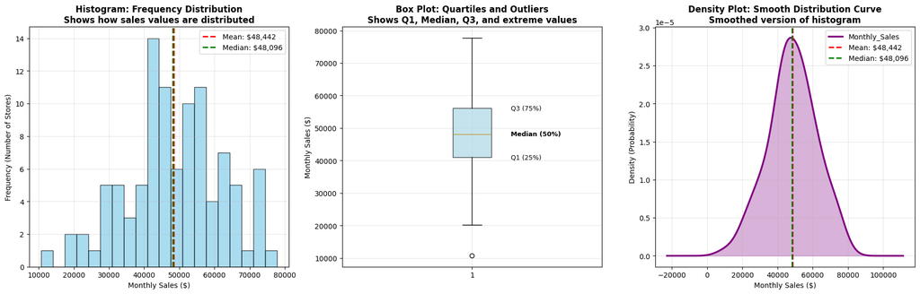

```
======================================================================
INTERPRETING THE THREE PLOTS TOGETHER
======================================================================

1. HISTOGRAM: Look at the shape
   - Is it bell-shaped, skewed, or has multiple peaks?
   - Where is the center of the data?

2. BOX PLOT: Identify quartiles and outliers
   - Where is the middle 50% of your data?
   - Are there unusual values (outliers)?

3. DENSITY PLOT: See the smooth overall shape
   - Where are the peaks (most common values)?
   - How spread out is the distribution?
======================================================================
```

```python
# Create comprehensive distribution visualization
fig, axes = plt.subplots(1, 3, figsize=(18, 6))

# 1. HISTOGRAM (Left)
axes[0].hist(sales_data['Monthly_Sales'], bins=20,
             alpha=0.7, color='skyblue', edgecolor='black')
axes[0].axvline(mean_sales, color='red', linestyle='--', linewidth=2,
                label=f'Mean: ${mean_sales:,.0f}')
axes[0].axvline(median_sales, color='green', linestyle='--', linewidth=2,
                label=f'Median: ${median_sales:,.0f}')
axes[0].set_title('Histogram: Frequency Distribution\nShows how sales values are distributed',
                  fontsize=12, fontweight='bold')
axes[0].set_xlabel('Monthly Sales ($)')
axes[0].set_ylabel('Frequency (Number of Stores)')
axes[0].legend()
axes[0].grid(True, alpha=0.3)

# 2. BOX PLOT (Center)
bp = axes[1].boxplot(sales_data['Monthly_Sales'], vert=True, patch_artist=True,
                     boxprops=dict(facecolor='lightblue', alpha=0.7))
axes[1].set_ylabel('Monthly Sales ($)')
axes[1].set_title('Box Plot: Quartiles and Outliers\nShows Q1, Median, Q3, and extreme values',
                  fontsize=12, fontweight='bold')
axes[1].grid(True, alpha=0.3)

# Add annotations to box plot
Q1 = sales_data['Monthly_Sales'].quantile(0.25)
Q3 = sales_data['Monthly_Sales'].quantile(0.75)
axes[1].text(1.15, Q1, f'Q1 (25%)', va='center', fontsize=9)
axes[1].text(1.15, median_sales, f'Median (50%)', va='center', fontsize=9, fontweight='bold')
axes[1].text(1.15, Q3, f'Q3 (75%)', va='center', fontsize=9)

# 3. DENSITY PLOT (Right)
sales_data['Monthly_Sales'].plot(kind='density', ax=axes[2],
                                  color='purple', linewidth=2.5)
axes[2].axvline(mean_sales, color='red', linestyle='--', linewidth=2,
                label=f'Mean: ${mean_sales:,.0f}')
axes[2].axvline(median_sales, color='green', linestyle='--', linewidth=2,
                label=f'Median: ${median_sales:,.0f}')
axes[2].fill_between(axes[2].get_lines()[0].get_xdata(),
                     axes[2].get_lines()[0].get_ydata(),
                     alpha=0.3, color='purple')
axes[2].set_xlabel('Monthly Sales ($)')
axes[2].set_ylabel('Density (Probability)')
axes[2].set_title('Density Plot: Smooth Distribution Curve\nSmoothed version of histogram',
                  fontsize=12, fontweight='bold')
axes[2].legend()
axes[2].grid(True, alpha=0.3)

plt.tight_layout()
plt.show()

print("\n" + "="*70)
print("INTERPRETING THE THREE PLOTS TOGETHER")
print("="*70)
print("\n1. HISTOGRAM: Look at the shape")
print("   - Is it bell-shaped, skewed, or has multiple peaks?")
print("   - Where is the center of the data?")
print("\n2. BOX PLOT: Identify quartiles and outliers")
print("   - Where is the middle 50% of your data?")
print("   - Are there unusual values (outliers)?")
print("\n3. DENSITY PLOT: See the smooth overall shape")
print("   - Where are the peaks (most common values)?")
print("   - How spread out is the distribution?")
print("="*70)
```

# Part 4: Correlation Analysis

## Understanding Relationships Between Variables

### Pearson Correlation

```
Correlation Matrix:
                 Marketing_Spend  Store_Size  Staff_Count     Sales
Marketing_Spend         1.000000   -0.034033    -0.000414  0.662441
Store_Size             -0.034033    1.000000     0.029952  0.668656
Staff_Count            -0.000414    0.029952     1.000000 -0.007657
Sales                   0.662441    0.668656    -0.007657  1.000000
```

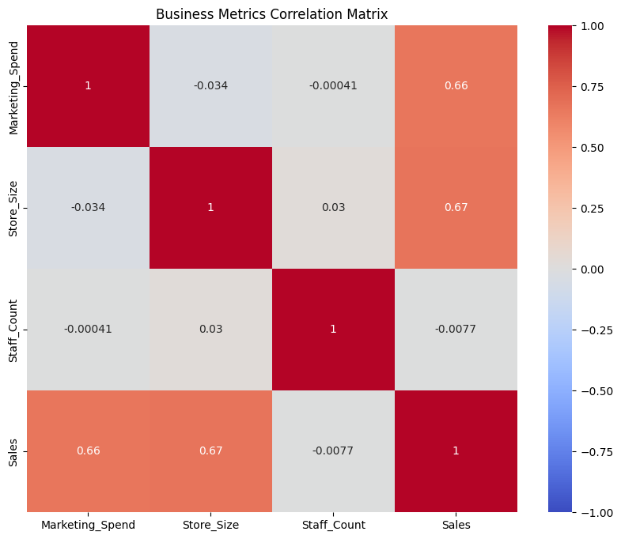

```python
# Create sample data with relationships
np.random.seed(42)
business_data = pd.DataFrame({
    'Marketing_Spend': np.random.uniform(1000, 10000, 100),
    'Store_Size': np.random.uniform(500, 5000, 100),
    'Staff_Count': np.random.randint(5, 50, 100)
})

# Create sales with correlation to marketing
business_data['Sales'] = (
    business_data['Marketing_Spend'] * 5 +
    business_data['Store_Size'] * 10 +
    np.random.normal(0, 5000, 100)
)

# Calculate correlation matrix
correlation_matrix = business_data.corr()
print("Correlation Matrix:")
print(correlation_matrix)

# Visualize correlations
plt.figure(figsize=(10, 8))
sns.heatmap(correlation_matrix, annot=True, cmap='coolwarm',
            center=0, vmin=-1, vmax=1)
plt.title('Business Metrics Correlation Matrix')
plt.show()
```

### Interpreting Correlations

- **Strong positive** (0.7 to 1.0): Variables move together
- **Moderate positive** (0.3 to 0.7): Some positive relationship
- **Weak/No correlation** (-0.3 to 0.3): Little to no linear relationship
- **Moderate negative** (-0.7 to -0.3): Some inverse relationship
- **Strong negative** (-1.0 to -0.7): Variables move in opposite directions

# Part 6: Exploratory Data Analysis (EDA)

## Comprehensive Data Understanding

### The EDA Process

```python
def perform_eda(df, target_column):
    """Perform comprehensive EDA on a dataset"""

    print("="*50)
    print(f"EXPLORATORY DATA ANALYSIS: {target_column}")
    print("="*50)

    # 1. Basic Information
    print("\n1. DATASET OVERVIEW")
    print(f"   Shape: {df.shape}")
    print(f"   Missing values: {df[target_column].isna().sum()}")

    # 2. Descriptive Statistics
    print("\n2. DESCRIPTIVE STATISTICS")
    print(df[target_column].describe())

    # 3. Outlier Detection
    Q1 = df[target_column].quantile(0.25)
    Q3 = df[target_column].quantile(0.75)
    IQR = Q3 - Q1
    lower_bound = Q1 - 1.5 * IQR
    upper_bound = Q3 + 1.5 * IQR
    outliers = df[(df[target_column] < lower_bound) |
                  (df[target_column] > upper_bound)]

    print("\n3. OUTLIER ANALYSIS")
    print(f"   Lower bound: {lower_bound:.2f}")
    print(f"   Upper bound: {upper_bound:.2f}")
    print(f"   Number of outliers: {len(outliers)}")
    print(f"   Percentage of outliers: {len(outliers)/len(df)*100:.2f}%")

# Apply EDA to sales data
perform_eda(sales_data, 'Monthly_Sales')
```

```
==================================================
EXPLORATORY DATA ANALYSIS: Monthly_Sales
==================================================

1. DATASET OVERVIEW
   Shape: (100, 4)
   Missing values: 0

2. DESCRIPTIVE STATISTICS
count      100.000000
mean     48442.302239
std      13622.526420
min      10703.823439
25%      40986.414943
50%      48095.655623
75%      56089.280780
max      77784.172768
Name: Monthly_Sales, dtype: float64

3. OUTLIER ANALYSIS
   Lower bound: 18332.12
   Upper bound: 78743.58
   Number of outliers: 1
   Percentage of outliers: 1.00%
```

# Part 7: Business Applications

## Real-World Statistical Analysis

### Customer Segmentation Analysis

```python
# Create customer segments based on spending
customer_data = pd.DataFrame({
    'Customer_ID': range(1, 501),
    'Annual_Spend': np.random.lognormal(8, 0.8, 500),
    'Purchase_Frequency': np.random.poisson(12, 500),
    'Avg_Order_Value': np.random.normal(75, 25, 500)
})

# Segment customers by spending
customer_data['Segment'] = pd.cut(
    customer_data['Annual_Spend'],
    bins=[0, 1000, 5000, 10000, float('inf')],
    labels=['Low', 'Medium', 'High', 'Premium']
)

# Analyze segments
segment_stats = customer_data.groupby('Segment').agg({
    'Annual_Spend': ['count', 'mean', 'std'],
    'Purchase_Frequency': 'mean',
    'Avg_Order_Value': 'mean'
})

print("Customer Segment Analysis:")
print(segment_stats)
```

```
Customer Segment Analysis:
        Annual_Spend                            Purchase_Frequency  \
               count          mean          std               mean
Segment
Low               47    719.556446   190.342463          13.276596
Medium           306   2618.106668  1074.499579          11.836601
High             103   6985.420962  1392.253345          12.155340
Premium           44  15067.311075  5080.280807          11.431818

        Avg_Order_Value
                   mean
Segment
Low           72.167171
Medium        76.357306
High          77.514991
Premium       79.342458
```

### Performance Benchmarking

```python
# Compare store performance
store_performance = pd.DataFrame({
    'Store': ['Store A', 'Store B', 'Store C', 'Store D'],
    'Q1_Sales': [120000, 98000, 145000, 110000],
    'Q2_Sales': [135000, 102000, 150000, 125000],
    'Q3_Sales': [128000, 110000, 142000, 130000],
    'Q4_Sales': [145000, 125000, 165000, 140000]
})

# Calculate statistics for each store
store_performance['Annual_Total'] = store_performance[['Q1_Sales', 'Q2_Sales',
                                                       'Q3_Sales', 'Q4_Sales']].sum(axis=1)
store_performance['Quarterly_Avg'] = store_performance['Annual_Total'] / 4
store_performance['Quarterly_Std'] = store_performance[['Q1_Sales', 'Q2_Sales',
                                                        'Q3_Sales', 'Q4_Sales']].std(axis=1)
store_performance['CV'] = (store_performance['Quarterly_Std'] /
                           store_performance['Quarterly_Avg']) * 100

print("Store Performance Comparison:")
print(store_performance[['Store', 'Annual_Total', 'Quarterly_Avg',
                         'Quarterly_Std', 'CV']])
```

```
Store Performance Comparison:
     Store  Annual_Total  Quarterly_Avg  Quarterly_Std         CV
0  Store A        528000       132000.0   10614.455552   8.041254
1  Store B        435000       108750.0   11926.860442  10.967228
2  Store C        602000       150500.0   10214.368964   6.786956
3  Store D        505000       126250.0   12500.000000   9.900990
```

# Practice Exercises

## Apply Your Statistical Knowledge

### Exercise 1: Sales Analysis

Given monthly sales data for multiple products:

1. Calculate mean, median, and mode for each product
2. Identify which products have the most consistent sales (lowest CV)
3. Find outliers using the IQR method
4. Create visualizations to present findings

### Exercise 2: Customer Behavior Analysis

With customer transaction data:

1. Analyze the distribution of purchase amounts
2. Calculate correlation between customer age and spending
3. Segment customers based on statistical measures
4. Identify high-value customer characteristics

### Exercise 3: Quality Control

Using production quality metrics:

1. Calculate control limits (mean ± 3*std)
2. Identify processes that are out of control
3. Analyze variation patterns
4. Recommend improvement areas

# Key Takeaways

## What You’ve Learned

# Next Week

## Week 10: Inferential Statistics and Hypothesis Testing

We’ll explore:

- **Hypothesis testing** fundamentals
- **T-tests** and **Z-tests**
- **Confidence intervals**
- **A/B testing** for business experiments
- **P-values** and statistical significance

# Resources and References

## Additional Learning Materials

- **Python Libraries**:
  - `pandas` for data manipulation
  - `numpy` for numerical operations
  - `scipy.stats` for statistical functions
  - `matplotlib` and `seaborn` for visualization
- **Further Reading**:
  - “Think Stats” by Allen B. Downey
  - “Practical Statistics for Data Scientists” by Bruce & Bruce
  - Khan Academy Statistics Course

### Contact

- Email: smith515@usf.edu
- Office Hours: See Canvas

ISM4641 Python for Business - Version 0.12.0